# Tema 16 - Aprendizaje No Supervisado

Universidad de Alicante, Curso 2021/22

## Aprendizaje no supervisado

- Objetivo: buscar patrones o relaciones en los datos sin una meta clara
  - Ej.: compradores con historias de navegación y compra similares
- En ocasiones, parte del análisis exploratorio de datos.
- Resultados más subjetivos: sin objetivos claros y sin mecanismos para validar los resultados (no hay respuesta correcta para comparar los resultados)
- *Clustering*: técnicas para identificar subgrupos homogéneos de observaciones a partir de sus características observadas.
  - La estructura o patrón a descubrir no se conoce de antemano.
- P.e., la segmentación de mercado pretende identificar subgrupos más receptivos a publicidad o comprar un producto a partir de información de renta, edad, género, etc.

## Clustering

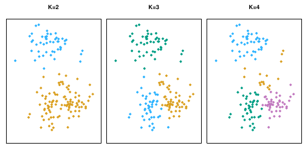

- Para K dado, se divide el conjunto de datos en K grupos distintos \(\small C_1,\dots,C_K\) (no solapados)
- Cada observación pertenece a un grupo
- La variación dentro de un cluster (*within-cluster sum of squares* o *wss*) es una medida de cuánto difieren las observaciones de un cluster entre sí

\[\scriptsize W(C_{k}) = \frac{1}{|n_{k}|}\sum_{i,i^{\prime} \in C_{k}} \sum_{j=1}^{p}(x_{ij} - x_{i^{\prime}j})^{2}\]

- La partición óptima minimiza la suma total de la variación *within* (*total wss*) \(\small \mathrm{min}_{C_{1},\ \dots,\ C_{K}} \bigg \{\sum_{k=1}^{K} W(C_{k}) \bigg \}\) \(\Rightarrow\) INVIABLE (\(\small K^n\) particiones)

## Algoritmo de K-Means

- Se puede encontrar un mínimo local
1. Conjetura inicial: asignar cada observación a un grupo (aleatoriamente)
2. Iterar hasta las asignaciones dejen de cambiar:

   a.- Calcular el centroide \(\small m_k\) de cada grupo(vector de medias de las observaciones del grupo \(\small k\))

   b.- Asignar cada observación al grupo cuyo centroide es el más cercano (distancia L2).

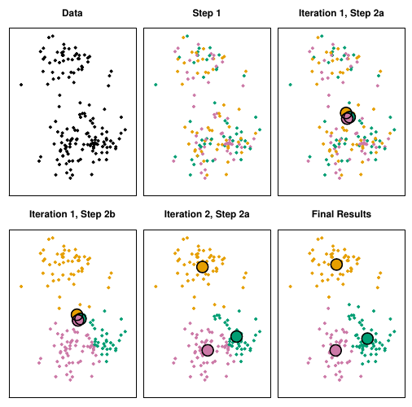

## Algoritmo de K-Means: diferentes mínimos

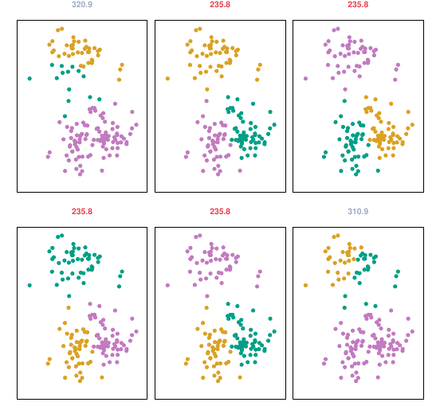

- Este algoritmo garantiza que la función objetivo disminuye en cada paso
- El resultado (óptimo local) depende de la asignación aleatoria inicial
- Se DEBE ejecutar el algoritmo con varias asignaciones iniciales y seleccionar la solución con menor valor de la función objetivo

## Número óptimo de *clusters*

- La agrupación óptima es relativamente “subjetiva”: depende de cómo se miden las similitudes, qué parámetros se utilizan para la partición, etc.
- Entre los muchos métodos existentes el “método del codo” (*elbow method*) es relativamente sencillo
1. Calcular el algoritmo de *clustering* para diferentes valores de \(\small k\).
2. Para cada \(\small k\), obtener la suma cuadrática total dentro del grupo (*total wss*)
3. Dibujar un gráfico de la *total wss* en función de \(\small k\)
4. Un cambio de curvatura se considera como un indicador de \(\small k\) óptimo

## Ejemplo de *clustering*

```r
clientes <- read_csv("https://www.dropbox.com/s/c55ju8yrmnbfys6/clientes.csv?dl=1")
clientes2 <- clientes %>%
                mutate(cluster = factor(kmeans(x = ., centers = 2)$cluster) )
clientes2 %>%
  ggplot(aes(y = valor_compra, x = dias_transcurridos)) +
  geom_point(aes(color = cluster))
```

[output not shown]

- El método del codo se implementa con la función `fviz_nbclust()`:

```r
library(factoextra)
fviz_nbclust(clientes, kmeans, method = "wss") +
    geom_vline(xintercept = 2)
```

[output not shown]

```r
iris.data <- iris %>% select(-5)
fviz_nbclust(iris.data, kmeans, method = "wss") +
    geom_vline(xintercept = 3)
```

[output not shown]